# Inference for Proportions using the Normal Distribution

Day 20

Claire Kelling

Carleton College  
STAT 120 - Fall 2026

## Question of the Day

What was your favorite Halloween costume? 😊

## Today’s Topics

Housekeeping:

- Proposals/Group agreements, Quiz 2 corrections due Wednesday!
- Quiz 3 grades posted later today

Topics covered today:

- Classical Inference for Proportions
- Classical Inference for Difference in Proportions

# Classical Inference for Proportions

## Background

**New Focus**

- Resampling inference methods like the bootstrap (CI) and randomization tests require the use of computers
- In the “olden days” when computers were not available, we had to rely on **statistical theory**
  - **CLT**: when n is big enough, means and proportions behave like a normal distribution.
  - Today we will **compute the SE using formulas** derived from probability theory

The inference methods in ch. 6+ are “classical” methods that could be done just with pen and paper.

## Resampling vs Classical Methods

**Which method?**

- Once we complete ch. 6 you will usually have two choices of methods for inference
  - **Results are often very similar (no practical difference)**
- When to choose resampling vs classical methods?
  - Resampling methods are intuitive and don’t require lots of statistical theory/background.
- But in many research fields you will likely only see classical methods used
  - In the “olden days”, classical methods were the only thing taught in stats methods classes.
  - Plus, more advanced methods usually do rely on classical theory due to their complexity.
  - Simulation-based methods are advantageous in some cases due to lack of assumptions

## Distribution of Sample Proportions

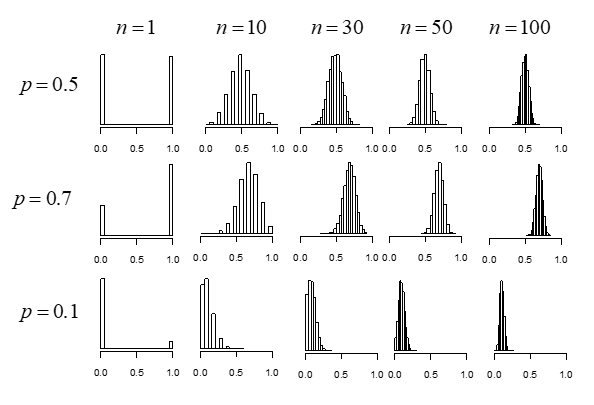

## CLT for Proportion(s)

**One Sample**

The sampling distribution for a sample proportion is approximately $N($$p$$, SE_{\hat{p}})$

- Need $n$ large enough so that $np \geq 10$ and $n(1-p) \geq 10$

**Two Samples**

The sampling distribution for the difference of two sample proportions is approximately $N($$p_1 - p_2$ $, SE_{\hat{p}_1 - \hat{p}_2})$

- Compare two separate samples of size $n_1$ and $n_2$
- Need **both $n$’s** large enough to satisfy the one sample conditions

## One Proportion or Two?

**Example**

You want to… compare the proportion of students who study abroad between those attending public universities and those at private universities.

This is

1. Inference for one proportion
2. Inference for two proportions

Two proportions. This is two categorical variables: study abroad or not, and public or private university.

## One Proportion or Two?

**Example**

You want to… compare the proportion of students who use a Windows-based PC to the proportion who use a Mac.

This is

1. Inference for one proportion
2. Inference for two proportions

One proportion. This is one categorical variable:  
type of computer used.

# Standard Error Calculations

## SE of Sample Proportion

**SE of Sample Proportion**

The standard error for $\hat{p}$ is

$$SE_{\hat{p}} = \sqrt{\frac{p(1-p)}{n}}$$

- The larger the sample size, the smaller the SE

## WNBA Free Throws

- WNBA players made **78.6%** of their free throws in the 2026 regular season.
- If we sampled 100 free throws, what would be the SE for the sample proportion of free throws made?

$$SE_{\hat{p}} = \sqrt{\frac{0.786(0.214)}{100}} \approx 0.041$$

- So, the margin of error (95% CI) would be about 2(4.1%)=8.2%.
- **Your turn:** What should $n$ be to get a margin of error of 3%? ($SE=$ 0.015)

$$0.015 = \sqrt{\frac{0.786(0.214)}{n}}, \text{ } n = \frac{0.786 \times 0.214}{0.015^2} \approx 748$$

Data: [Basketball-Reference, 2026 WNBA season](https://www.basketball-reference.com/wnba/years/2026.html)

## SE for a Difference in Sample Props

**SE for Difference in Sample Proportions**

The standard error for $\hat{p}_1 - \hat{p}_2$ is

$$SE_{\hat{p}_1 - \hat{p}_2} = \sqrt{\frac{p_1(1-p_1)}{n_1} + \frac{p_2(1-p_2)}{n_2}}$$

## WNBA Finals: Free Throws

**Valkyries vs. Dream**

- In the 2026 regular season, the two WNBA Finals teams made **77.4%** (Golden State Valkyries) and **78.6%** (Atlanta Dream) of their free throws.
- If we sampled 100 Valkyries free throws and 200 Dream free throws, what would be the SE for the difference in sample proportions?

**Setup**

- $p_{GSV} = 0.774,\text{ } p_{ATL} = 0.786$
- $n_{GSV} = 100,\text{ } n_{ATL} = 200$

$$SE= \sqrt{\frac{0.774(0.226)}{100} + \frac{0.786(0.214)}{200}} \approx 0.051$$

- The teams differ by only 1.2 percentage points, but the SE is about 5 percentage points. A difference this small could easily be due to sampling variability!

Data: [Basketball-Reference, 2026 WNBA season](https://www.basketball-reference.com/wnba/years/2026.html)

# Hypothesis Testing and CIs

## Global Warming Example

Do a majority of Americans believe in global warming?

**Hypothesis Testing**

- $H_0: p = 0.50, H_a: p > 0.50$
- $p$ = proportion of all Americans who believe in global warming

Survey:

- A survey on 2,251 randomly selected individuals conducted in October 2010 found that 1,328 answered “Yes” to the question “*Is there solid evidence of global warming?*”

## Global Warming Example

**Hypothesis Testing**

- $H_0: p = 0.50, H_a: p > 0.50$
- Sample proportion: $\hat{p} = \frac{1328}{2251} = 0.590$
- Calculate the SE **under the null**: $SE = \sqrt{ \frac{0.50(0.50)}{2251}} = 0.0105$
- Standardized test statistic: $z = \frac{(0.59 - 0.50)}{0.0105} = 8.54$
- P-value: proportion above $z= 8.54$ on $N(0,1)$ curve

```r
1-pnorm(________, 0, 1)
```

Let’s do this on Statkey with $N(0,1)$!

**Interpretation:**

Yes, there is strong evidence that the percentage of Americans that believe in global warming is greater than 50% (z=8.54, p<0.0001).

## Global Warming Example

**Confidence Interval**

- How much greater? Need a confidence interval!
- What proportion do we use to compute the SE?

$$SE = \sqrt{\frac{p(1-p)}{n}}$$

- We use the sample proportion, $\hat{p} = \frac{1328}{2251} = 0.59$
- Therefore $SE = \sqrt{\frac{\hat{p}(1-\hat{p})}{n}} = \sqrt{\frac{0.59(1-0.59)}{2251}} = 0.0104$
- 95% CI: $0.59 \pm 1.96 \times 0.0104 = (0.570, 0.610)$
- We are 95% confident that between 57% and 61% of Americans believe in global warming.

## Global Warming CI with Bootstrapping (Chapter 3)

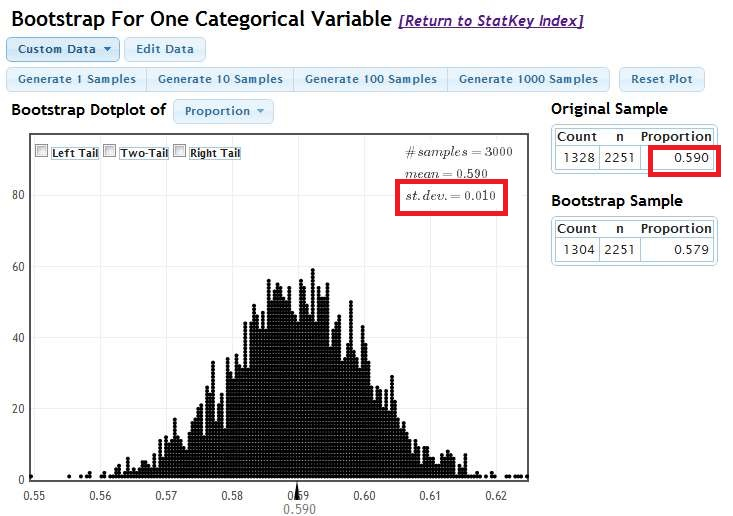

- **Bootstrap CI**: 0.59 $\pm$ 1.96(0.01) = (0.57, 0.61)
- Interpretation: We are 95% sure that the true percentage of all Americans that believe there is solid evidence of global warming is between 57.0% and 61.0%

## Example: Tagging Penguins

**Context**

- A study looked at the 10 year survival rate of penguins tagged either with a metal tag or an electronic tag. 20% of the 167 metal tagged penguins survived, compared to 36% of the 189 electronic tagged penguins.
- Is there a statistically discernible difference in survival rates?
- Denote $p$ as a survival rate

**Exercise**

**Your Turn:** What are the null and alternative hypotheses?

- $H_0: p_M = p_E$
- $H_a: p_M \neq p_E$

Source: Saraux, et. al. (2011). “Reliability of flipper-banded penguins as indicators of climate change,” Nature, 469, 203-206.

## Tagging Penguins

**Context**

20% of the 167 metal tagged penguins survived, compared to 36% of the 189 electronic tagged penguins.

**Question**

**Are the conditions met for using the normal distribution for inference?**

Yes: With metal tags, 33 survived and 134 died. With electronic tags, 68 survived and 121 died. All counts are greater than 10.

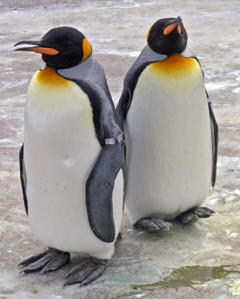

## Pooled Proportion (Hypothesis Testing)

**Penguin**

- We don’t know the population $p_M$ or $p_E$, so how do we compute the SE for our hypothesis test?
- **Assume the two proportions are equal and use one proportion for both groups.**
- Our best guess of this one proportion comes from combining data from both groups and computing the overall proportion, called the **pooled proportion**, p.
- **Tip**: the pooled proportion will always be somewhere in between the two sample proportions.

## Tagging Penguins

**Context**

20% of the 167 metal tagged penguins survived, compared to 36% of the 189 electronic tagged penguins.

- 33 survived with metal tags and 68 with electronic

Pooled proportion:

$$\hat{p} = \frac{33+68}{167+189} = 0.2837$$

SE for our test:

$$SE = \sqrt{\frac{0.284(1-0.284)}{167} + \frac{0.284(1-0.284)}{189}} = 0.048$$

## Tagging Penguins

**Context**

20% of the 167 metal tagged penguins survived, compared to 36% of the 189 electronic tagged penguins.

- The pooled SE is 0.048.

Standardized test statistic:

$$z = \frac{(0.2-0.36) - 0}{0.048} = -3.34$$

**p-value**: 2$\times$ proportion below -3.34

```r
2*pnorm(-3.34, 0, 1)
```

```
[1] 0.0008377839
```

Decision: **Reject the null.** There is a statistically discernible difference in the percent that survived between metal and electronic tagged penguins.

## Tagging Penguins

**Context**

A difference in survival rates as extreme, or more extreme, than 16% would occur by chance only about 0.08% of the time. There is a **statistically discernible difference** (z=-3.34, p=0.0008).

How much do the rates differ?

- Compute a 95% CI for the difference.
- How do we compute the SE?
- We can’t use the pooled version since we’ve concluded the proportions differ!

## Tagging Penguins

**Context**

20% of the 167 metal tagged penguins survived, compared to 36% of the 189 electronic tagged penguins.

**95% CI for $p_M - p_E$**

$$\text{statistic} \pm z^* (SE)$$

- $(0.20-0.36) \pm 1.96 \sqrt{\frac{0.20\times0.80}{167} + \frac{0.36\times0.64}{189}} = -0.16 \pm 1.96 \times 0.047 = (-0.251, -0.069)$
- We are 95% confident that between 6.9% to 25.1% fewer penguins survive when metal tags are used compared to electronic tags.

# Summary

## Test for Single Proportion

**HT Framework**

$$H_0: p = p_0$$

- Standardized test statistic: $z = \frac{\hat{p} - p_0}{\sqrt{\frac{p_0(1-p_0)}{n}}}$

What is sufficiently large n?

- If $np_0 \geq 10$ and $n(1-p_0) \geq 10$, then the p-value can be computed as the area in the tail(s) of a standard normal beyond $z$.

## Confidence Interval for $p$

**CI Framework**

$$\text{statistic} \pm z^* (SE)$$

For large enough $n$,

$$\hat{p} \pm z^* \sqrt{\frac{\hat{p}(1-\hat{p})}{n}}$$

## Test for a Difference in Proportions

**HT Framework**

$$H_0: p_1 = p_2$$

Standardized test statistic:

$$z = \frac{(\hat{p}_1 - \hat{p}_2) - 0}{\sqrt{\frac{\hat{p}(1-\hat{p})}{n_1} + \frac{\hat{p}(1-\hat{p})}{n_2}}}$$

What is sufficiently large n?

- If observed counts in the two-way table are **at least 10**, then the p-value can be computed as the area in the tail(s) of a standard normal beyond z.
- Note we used **pooled proportion** for the SE.

## Confidence Interval for $p_1 - p_2$

**CI Framework**

$$\text{statistic} \pm z^* (SE)$$

For large enough $n_1$ and $n_2$:

$$(\hat{p}_1 - \hat{p}_2) \pm z^* \sqrt{\frac{\hat{p}_1(1-\hat{p}_1)}{n_1}+\frac{\hat{p}_2(1-\hat{p}_2)}{n_2}}$$

## Next Class

Classical inference for means